# STAT-253_Project

Aalyan, Eric

2/3/2022

```r
library(tidyverse)
library(ggplot2)
library(dplyr)

set.seed(123)
```

```r
Pokemon_890 <- read_csv("Data/pokedex_(Update_05.20).csv") %>%
  mutate(Name = name) %>%
  select(-name)
Pokemon_721 <- read_csv("Data/Pokemon.csv")
```

```r
Pokemon_final <- Pokemon_721 %>%
  left_join(Pokemon_890,
            by = "Name") %>%
  select(c("#", Name, `Type 1`, `Type 2`, Total, HP, Attack, Defense, `Sp. Atk`, `Sp. Def`, Speed, Generation, Legendary, status, species, height_m, weight_kg, abilities_number, catch_rate, base_friendship, growth_rate)) %>%
  distinct()
```

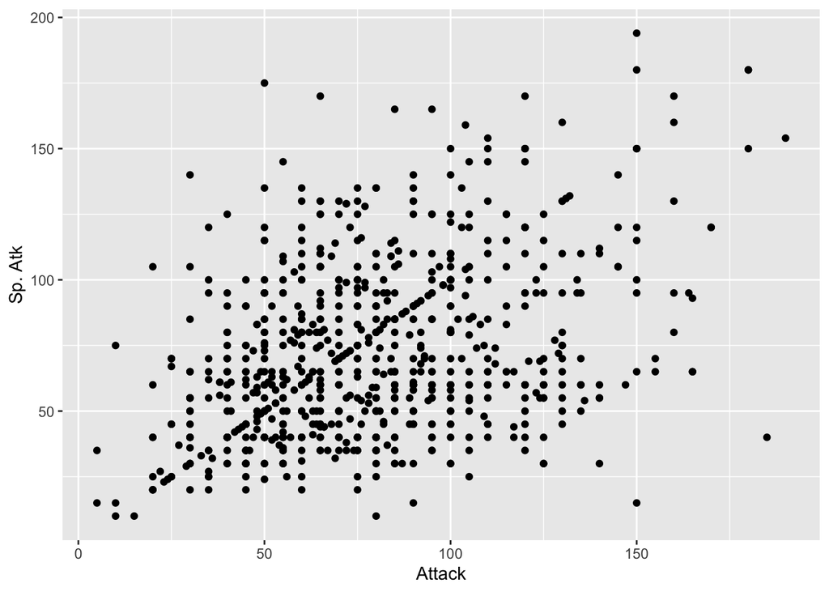

```r
Pokemon_final %>%
  ggplot(aes(x = Attack,
             y = `Sp. Atk`)) +
  geom_point()
```

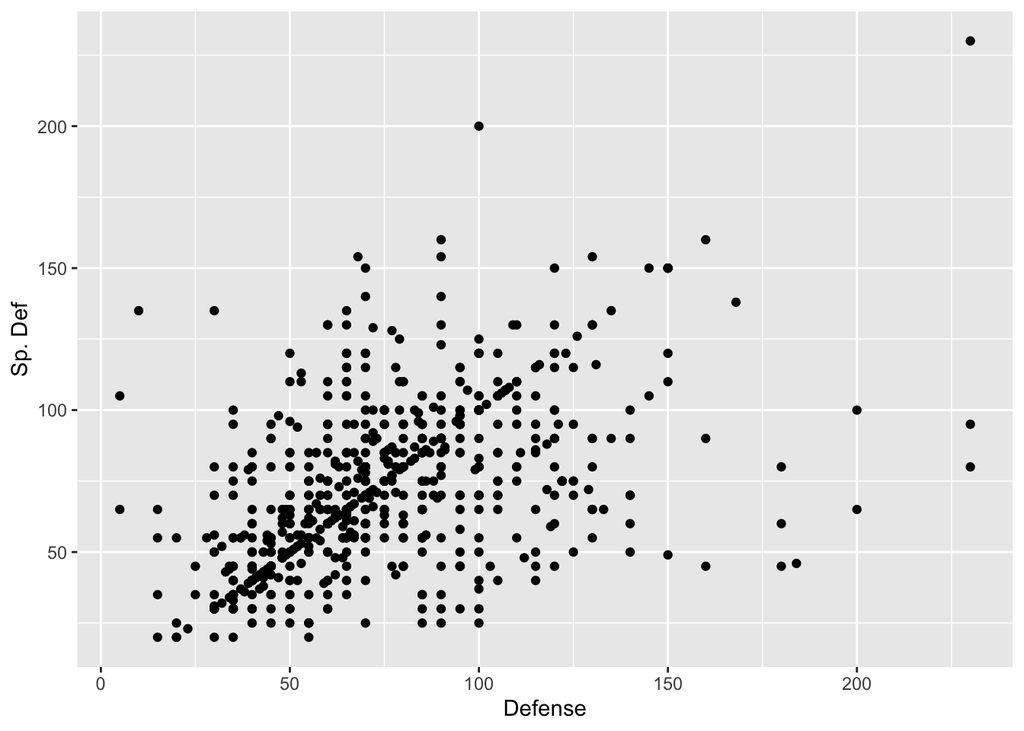

```r
Pokemon_final %>%
  ggplot(aes(x = Defense,
             y = `Sp. Def`)) +
  geom_point()
```

```r
Pokemon_1 <- Pokemon_final %>%
  select(Attack, `Sp. Atk`)
```

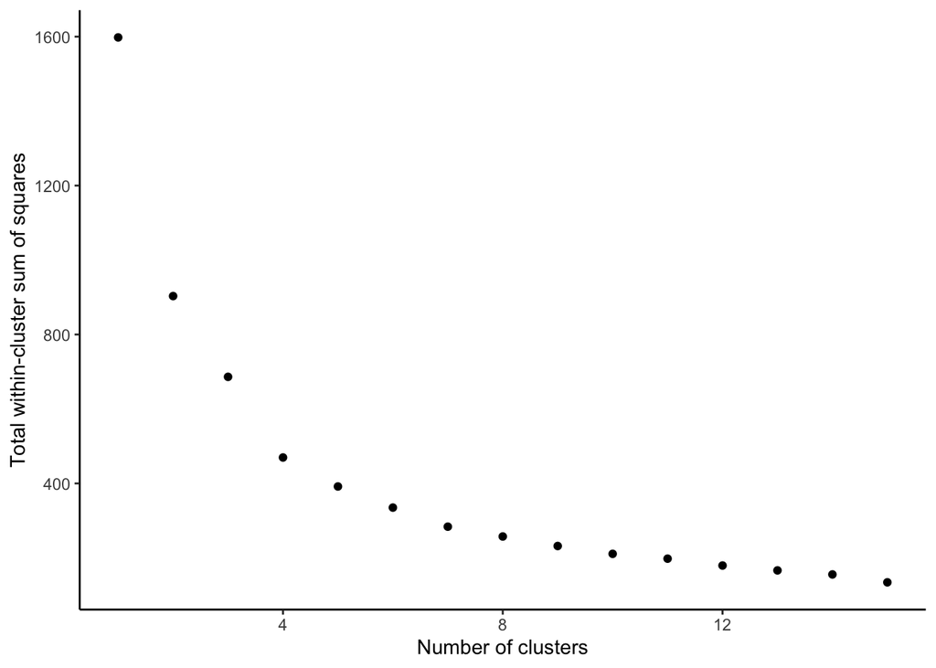

```r
# Data-specific function to cluster and calculate total within-cluster SS
pokemon_cluster_ss <- function(k){
    # Perform clustering
    kclust <- kmeans(scale(Pokemon_1), centers = k)

    # Return the total within-cluster sum of squares
    return(kclust$tot.withinss)
}

tibble(
    k = 1:15,
    tot_wc_ss = purrr::map_dbl(1:15, pokemon_cluster_ss)
) %>%
    ggplot(aes(x = k, y = tot_wc_ss)) +
    geom_point() +
    labs(x = "Number of clusters",y = 'Total within-cluster sum of squares') +
    theme_classic()
```

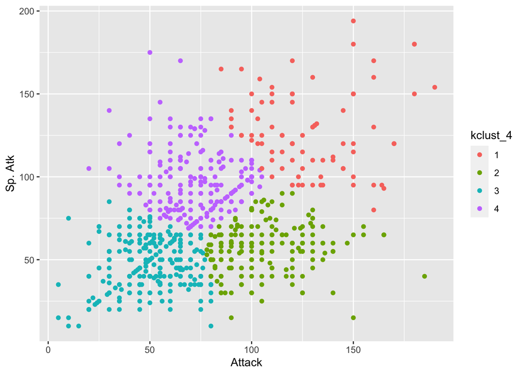

```r
kclust_1_k4 <- kmeans(Pokemon_1, centers = 4)
Pokemon_1 <- Pokemon_1 %>%
    mutate(kclust_4 = factor(kclust_1_k4$cluster))

Pokemon_1 %>%
  ggplot(aes(x = Attack,
             y = `Sp. Atk`,
             color = kclust_4)) +
  geom_point()
```

```r
Pokemon_final %>%
  mutate(kclust_4 = factor(kclust_1_k4$cluster)) %>%
  group_by(kclust_4, `Type 1`) %>%
  summarize(sum = n())
```

```
## # A tibble: 69 × 3
## # Groups:   kclust_4 [4]
##    kclust_4 `Type 1`   sum
##    <fct>    <chr>    <int>
##  1 1        Bug          1
##  2 1        Dark         7
##  3 1        Dragon      15
##  4 1        Electric     6
##  5 1        Fairy        1
##  6 1        Fighting     3
##  7 1        Fire        13
##  8 1        Flying       1
##  9 1        Ghost        2
## 10 1        Grass        6
## # … with 59 more rows
```

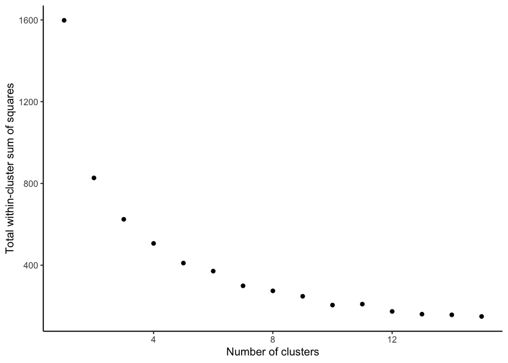

```r
Pokemon_2 <- Pokemon_final %>%
  select(Defense, `Sp. Def`)

# Data-specific function to cluster and calculate total within-cluster SS
pokemon_cluster_ss <- function(k){
    # Perform clustering
    kclust <- kmeans(scale(Pokemon_2), centers = k)

    # Return the total within-cluster sum of squares
    return(kclust$tot.withinss)
}

tibble(
    k = 1:15,
    tot_wc_ss = purrr::map_dbl(1:15, pokemon_cluster_ss)
) %>%
    ggplot(aes(x = k, y = tot_wc_ss)) +
    geom_point() +
    labs(x = "Number of clusters",y = 'Total within-cluster sum of squares') +
    theme_classic()
```

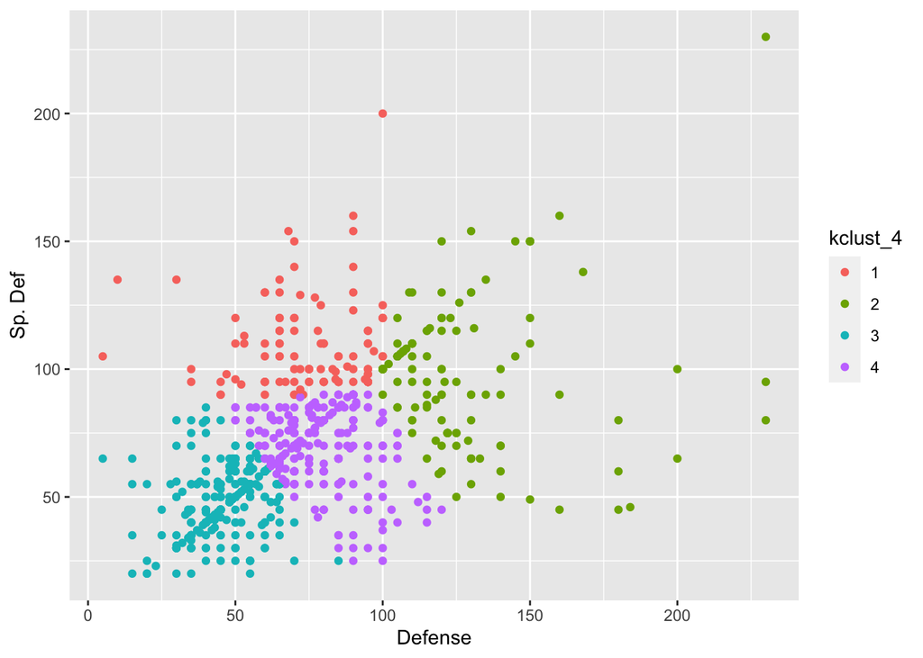

```r
kclust_2_k4 <- kmeans(Pokemon_2, centers = 4)
Pokemon_2 <- Pokemon_2 %>%
    mutate(kclust_4 = factor(kclust_2_k4$cluster))

Pokemon_2 %>%
  ggplot(aes(x = Defense,
             y = `Sp. Def`,
             color = kclust_4)) +
  geom_point()
```

```r
Pokemon_final %>%
  mutate(kclust_4 = factor(kclust_2_k4$cluster)) %>%
  group_by(kclust_4, `Type 1`) %>%
  summarize(sum = n())
```

```
## # A tibble: 67 × 3
## # Groups:   kclust_4 [4]
##    kclust_4 `Type 1`   sum
##    <fct>    <chr>    <int>
##  1 1        Bug          7
##  2 1        Dark         1
##  3 1        Dragon       9
##  4 1        Electric     4
##  5 1        Fairy        7
##  6 1        Fighting     3
##  7 1        Fire         7
##  8 1        Ghost        2
##  9 1        Grass        6
## 10 1        Ground       1
## # … with 57 more rows
```

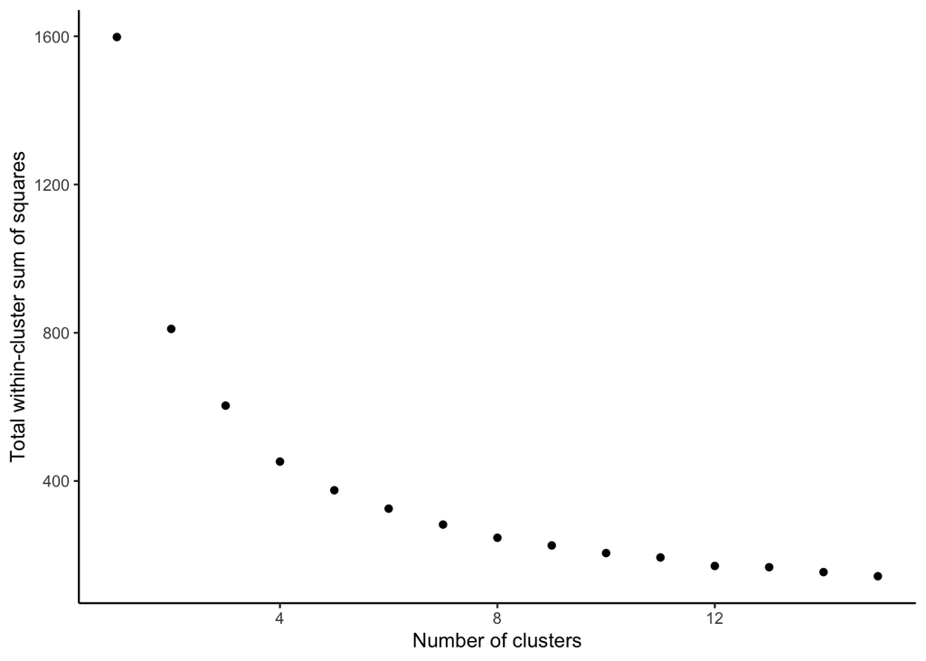

```r
Pokemon_3 <- Pokemon_final %>%
  select(`Sp. Atk`, Speed)

# Data-specific function to cluster and calculate total within-cluster SS
pokemon_cluster_ss <- function(k){
    # Perform clustering
    kclust <- kmeans(scale(Pokemon_3), centers = k)

    # Return the total within-cluster sum of squares
    return(kclust$tot.withinss)
}

tibble(
    k = 1:15,
    tot_wc_ss = purrr::map_dbl(1:15, pokemon_cluster_ss)
) %>%
    ggplot(aes(x = k, y = tot_wc_ss)) +
    geom_point() +
    labs(x = "Number of clusters",y = 'Total within-cluster sum of squares') +
    theme_classic()
```

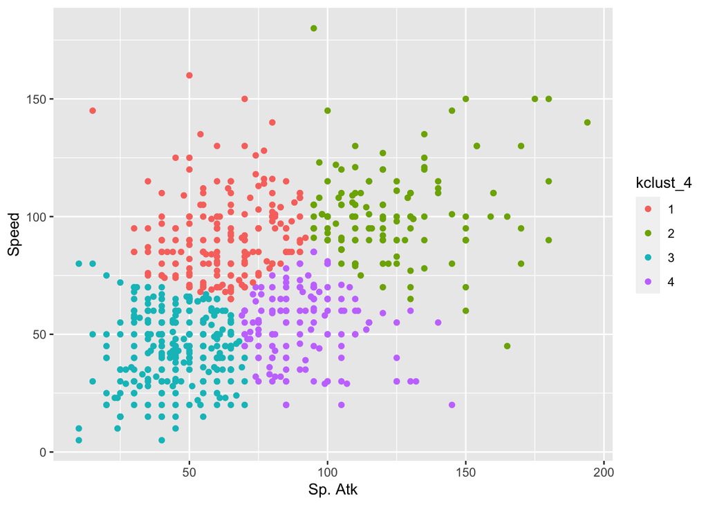

```r
kclust_3_k4 <- kmeans(Pokemon_3, centers = 4)
Pokemon_3 <- Pokemon_3 %>%
    mutate(kclust_4 = factor(kclust_3_k4$cluster))

Pokemon_3 %>%
  ggplot(aes(x = `Sp. Atk`,
             y = Speed,
             color = kclust_4)) +
  geom_point()
```

```r
Pokemon_final %>%
  mutate(kclust_4 = factor(kclust_3_k4$cluster)) %>%
  group_by(kclust_4, `Type 1`) %>%
  summarize(sum = n())
```

```
## # A tibble: 68 × 3
## # Groups:   kclust_4 [4]
##    kclust_4 `Type 1`   sum
##    <fct>    <chr>    <int>
##  1 1        Bug         18
##  2 1        Dark         9
##  3 1        Dragon       6
##  4 1        Electric    14
##  5 1        Fighting     7
##  6 1        Fire        12
##  7 1        Ghost        5
##  8 1        Grass       12
##  9 1        Ground      10
## 10 1        Ice          4
## # … with 58 more rows
```

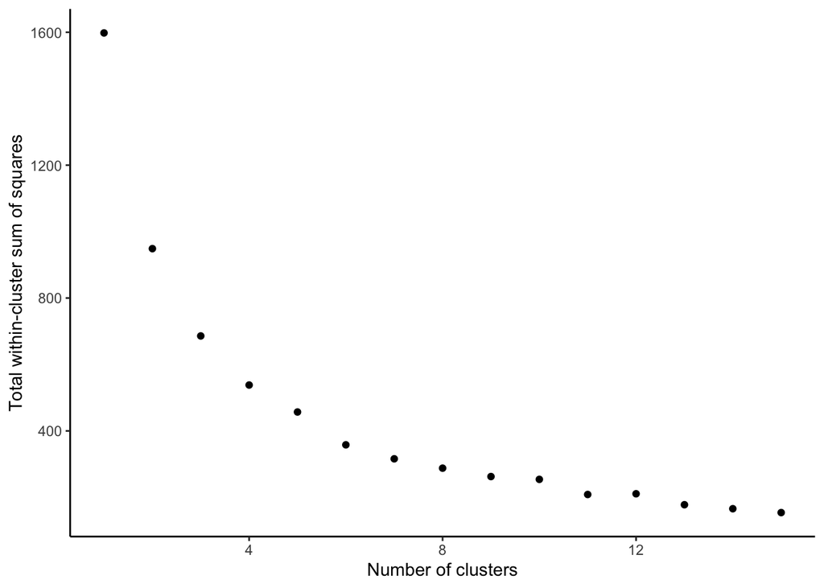

```r
Pokemon_4 <- Pokemon_final %>%
  select(Defense, HP)

# Data-specific function to cluster and calculate total within-cluster SS
pokemon_cluster_ss <- function(k){
    # Perform clustering
    kclust <- kmeans(scale(Pokemon_4), centers = k)

    # Return the total within-cluster sum of squares
    return(kclust$tot.withinss)
}

tibble(
    k = 1:15,
    tot_wc_ss = purrr::map_dbl(1:15, pokemon_cluster_ss)
) %>%
    ggplot(aes(x = k, y = tot_wc_ss)) +
    geom_point() +
    labs(x = "Number of clusters",y = 'Total within-cluster sum of squares') +
    theme_classic()
```

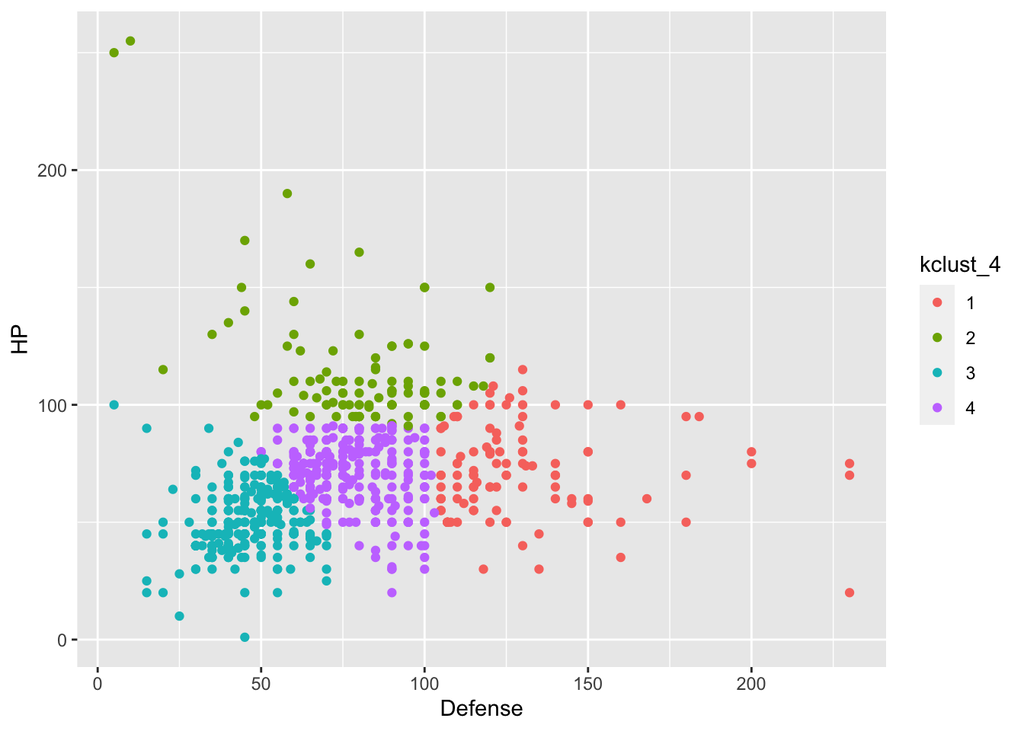

```r
kclust_4_k4 <- kmeans(Pokemon_4, centers = 4)
Pokemon_4 <- Pokemon_4 %>%
    mutate(kclust_4 = factor(kclust_4_k4$cluster))

Pokemon_4 %>%
  ggplot(aes(x = Defense,
             y = HP,
             color = kclust_4)) +
  geom_point()
```

```r
Pokemon_final %>%
  mutate(kclust_4 = factor(kclust_4_k4$cluster)) %>%
  group_by(kclust_4, `Type 1`) %>%
  summarize(sum = n())
```

```
## # A tibble: 66 × 3
## # Groups:   kclust_4 [4]
##    kclust_4 `Type 1`   sum
##    <fct>    <chr>    <int>
##  1 1        Bug          9
##  2 1        Dark         3
##  3 1        Dragon       5
##  4 1        Electric     7
##  5 1        Fire         5
##  6 1        Ghost        8
##  7 1        Grass        7
##  8 1        Ground      10
##  9 1        Ice          2
## 10 1        Normal       1
## # … with 56 more rows
```

## Insights from the K-Means Clustering approach:

> After choosing the most appropriate value for k (the value at the elbow of the number of clusters plot), we then plotted different variables against each other and formed clusters. Next, we output the number pokemon of each type in each cluster to observe which type was dominant in a particular field (e.g best attacker would be one with the highet attack and special attack).

> With all this set up, we observed that the strogest attacker type was, unsurprisingly, Dragon as dragin types were in the highest quantity in the cluster 1 of attack vs Sp. Attack. The weakest type here was bug.

> Next, when looking at the best defensive ability, we observed that the best type for defense (i.e in most quantity in cluster 2 for defense vs sp. defense) was rock or steel, and this is rather consistent with previous assumptions as Pokemon such as Aggron (A rock and steel type) boast a really high defense base stat. The weakest again here was bug type.

> Therefore as a final insight, we were able to use K-Means clustering to form the perfect Pokemon team, which would consist of a Dragon type (such as Salamence), a tanky normal type such as Snorlax to hold off opponents which we cannot combat with super effective moves, a rock type (and preferably steel dual type) to sustain hits, and then a mix of other types such as psychic which also boasts high attack. However, our strategy shows us very clearly that bug types ar to be aboided, and that is also the general consensus in the Pokemon community.